# Practical Machine Learning-Course Project

Jerin Rose

9/26/2020

## Overview

Using devices such as Jawbone Up, Nike FuelBand, and Fitbit it is now possible to collect a large amount of data about personal activity relatively inexpensively. These type of devices are part of the quantified self movement – a group of enthusiasts who take measurements about themselves regularly to improve their health, to find patterns in their behavior, or because they are tech geeks. One thing that people regularly do is quantify how much of a particular activity they do, but they rarely quantify how well they do it.

The goal of this project is to predict the manner in which they did the exercise. This is the “classe” variable in the training set.It contains report describing how I built my model, how I used cross validation, and the expected out of sample error is.

## How the model was built

Our outcome variable is ‘classe’, a factor variable with 5 levels. For this data set, **“participants were asked to perform one set of 10 repetitions of the Unilateral Dumbbell Biceps Curl in 5 different fashions”**

- exactly according to the specification (Class A)
- throwing the elbows to the front (Class B)
- lifting the dumbbell only halfway (Class C)
- lowering the dumbbell only halfway (Class D)
- throwing the hips to the front (Class E)

## Data loading and preprocessing

```r
library(caret)
library(RColorBrewer)
library(rattle)
```

```r
library(knitr)
library(rpart)
library(rpart.plot)
library(randomForest)
library(corrplot)
Trainurl <- "http://d396qusza40orc.cloudfront.net/predmachlearn/pml-training.csv"
Testurl  <- "http://d396qusza40orc.cloudfront.net/predmachlearn/pml-testing.csv"


training <- read.csv(url(Trainurl))
testing  <- read.csv(url(Testurl))

# create a partition with the training dataset
inTrain  <- createDataPartition(training$classe, p=0.7, list=FALSE)
Trainset <- training[inTrain, ]
Testset  <- training[-inTrain, ]
```

## Data cleaning

```r
dim(Trainset)
```

```
## [1] 13737   160
```

```r
dim(Testset)
```

```
## [1] 5885  160
```

So we can see both the sets have 160 variables and they contain NA values so we need to remove it.

```r
zerovar <- nearZeroVar(Trainset)
Trainset <- Trainset[, -zerovar]
Testset  <- Testset[, -zerovar]
dim(Trainset)
```

```
## [1] 13737   105
```

```r
dim(Testset)
```

```
## [1] 5885  105
```

So now remove the NA values

```r
AllNA    <- sapply(Trainset, function(x) mean(is.na(x))) > 0.95
Trainset <- Trainset[, AllNA==FALSE]
Testset  <- Testset[, AllNA==FALSE]
Trainset <- Trainset[, -(1:5)]
Testset  <- Testset[, -(1:5)]
dim(Trainset)
```

```
## [1] 13737    54
```

```r
dim(Testset)
```

```
## [1] 5885   54
```

So after cleaning we have reduced the variables.

## Correlation Analysis

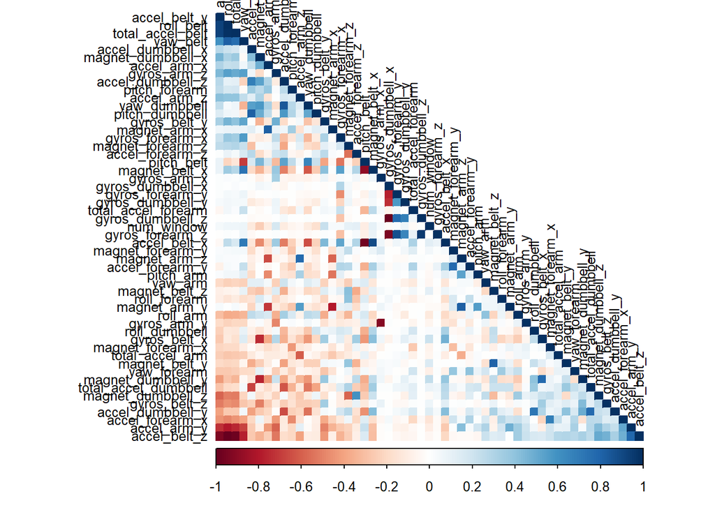

```r
cormatrix <- cor(Trainset[, -54])
corrplot(cormatrix, order = "FPC", method = "color", type = "lower",
         tl.cex = 0.8, tl.col = rgb(0, 0, 0))
```

In the graph above highly correlated variables are shown in dark colors

## Model Building

### Random Forest

```r
# Fitting the model
set.seed(12345)
controlrf <- trainControl(method="cv", number=3, verboseIter=FALSE)
modfitRandForest <- train(classe ~ ., data=Trainset, method="rf",trControl=controlrf)

modfitRandForest$finalModel
```

```
##
## Call:
##  randomForest(x = x, y = y, mtry = param$mtry)
##                Type of random forest: classification
##                      Number of trees: 500
## No. of variables tried at each split: 27
##
##         OOB estimate of  error rate: 0.17%
## Confusion matrix:
##      A    B    C    D    E  class.error
## A 3904    1    0    0    1 0.0005120328
## B    4 2652    2    0    0 0.0022573363
## C    0    5 2391    0    0 0.0020868114
## D    0    0    7 2245    0 0.0031083481
## E    0    0    0    4 2521 0.0015841584
```

```r
# Prediction on Test dataset
predictRandForest <- predict(modfitRandForest, newdata=Testset)
confRandForest <- confusionMatrix(predictRandForest, as.factor(Testset$classe))
confRandForest
```

```
## Confusion Matrix and Statistics
##
##           Reference
## Prediction    A    B    C    D    E
##          A 1674    2    0    0    0
##          B    0 1134    2    0    0
##          C    0    3 1024    3    0
##          D    0    0    0  961    6
##          E    0    0    0    0 1076
##
## Overall Statistics
##
##                Accuracy : 0.9973
##                  95% CI : (0.9956, 0.9984)
##     No Information Rate : 0.2845
##     P-Value [Acc > NIR] : < 2.2e-16
##
##                   Kappa : 0.9966
##
##  Mcnemar's Test P-Value : NA
##
## Statistics by Class:
##
##                      Class: A Class: B Class: C Class: D Class: E
## Sensitivity            1.0000   0.9956   0.9981   0.9969   0.9945
## Specificity            0.9995   0.9996   0.9988   0.9988   1.0000
## Pos Pred Value         0.9988   0.9982   0.9942   0.9938   1.0000
## Neg Pred Value         1.0000   0.9989   0.9996   0.9994   0.9988
## Prevalence             0.2845   0.1935   0.1743   0.1638   0.1839
## Detection Rate         0.2845   0.1927   0.1740   0.1633   0.1828
## Detection Prevalence   0.2848   0.1930   0.1750   0.1643   0.1828
## Balanced Accuracy      0.9998   0.9976   0.9984   0.9978   0.9972
```

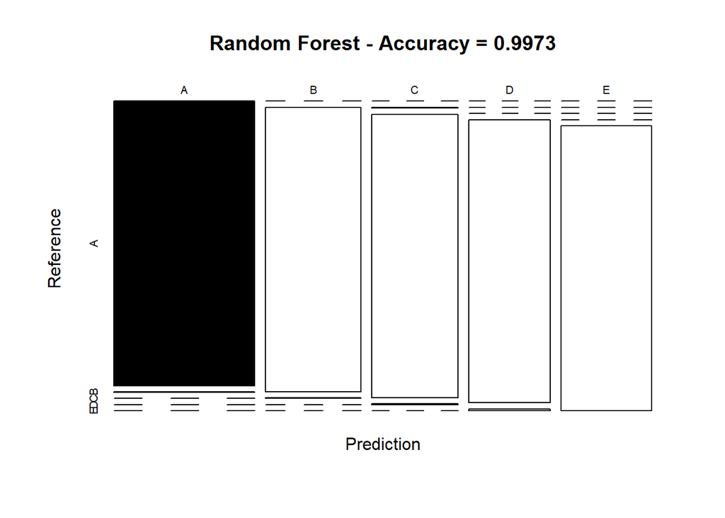

```r
# Plotting matrix results
plot(confRandForest$table, col = confRandForest$byClass,main = paste("Random Forest - Accuracy =",round(confRandForest$overall['Accuracy'], 4)))
```

### Decision Tree

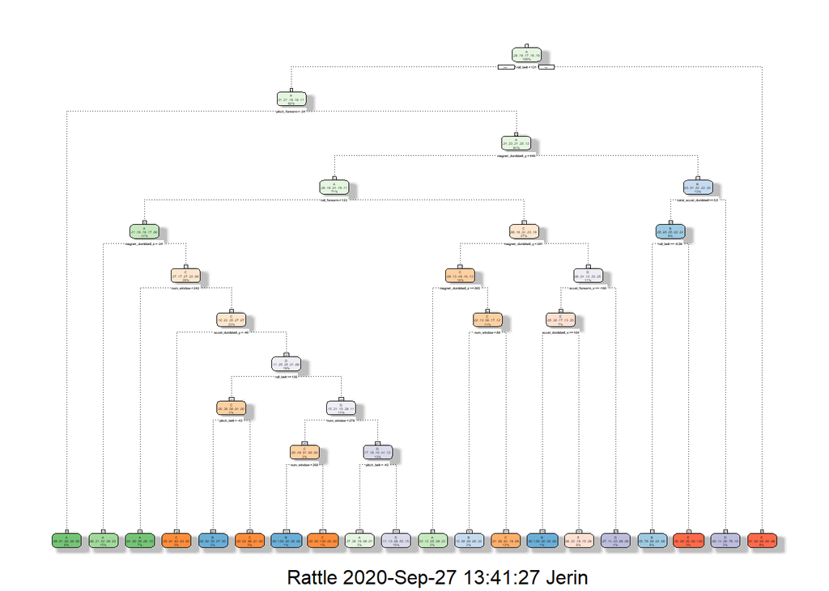

```r
# Fitting the model
set.seed(12345)
modfitdeTree <- rpart(classe ~ ., data=Trainset, method="class")
fancyRpartPlot(modfitdeTree)
```

```r
# Prediction on Test dataset
predictdeTree <- predict(modfitdeTree, newdata=Testset, type="class")
confdeTree <- confusionMatrix(predictdeTree, as.factor(Testset$classe))
confdeTree
```

```
## Confusion Matrix and Statistics
##
##           Reference
## Prediction    A    B    C    D    E
##          A 1532  253   61  126   95
##          B   34  589   41   22   87
##          C   10   73  813  126   66
##          D   71  133   55  618  130
##          E   27   91   56   72  704
##
## Overall Statistics
##
##                Accuracy : 0.7232
##                  95% CI : (0.7116, 0.7346)
##     No Information Rate : 0.2845
##     P-Value [Acc > NIR] : < 2.2e-16
##
##                   Kappa : 0.6473
##
##  Mcnemar's Test P-Value : < 2.2e-16
##
## Statistics by Class:
##
##                      Class: A Class: B Class: C Class: D Class: E
## Sensitivity            0.9152   0.5171   0.7924   0.6411   0.6506
## Specificity            0.8730   0.9612   0.9434   0.9210   0.9488
## Pos Pred Value         0.7412   0.7620   0.7472   0.6137   0.7411
## Neg Pred Value         0.9628   0.8924   0.9556   0.9291   0.9234
## Prevalence             0.2845   0.1935   0.1743   0.1638   0.1839
## Detection Rate         0.2603   0.1001   0.1381   0.1050   0.1196
## Detection Prevalence   0.3512   0.1314   0.1849   0.1711   0.1614
## Balanced Accuracy      0.8941   0.7392   0.8679   0.7810   0.7997
```

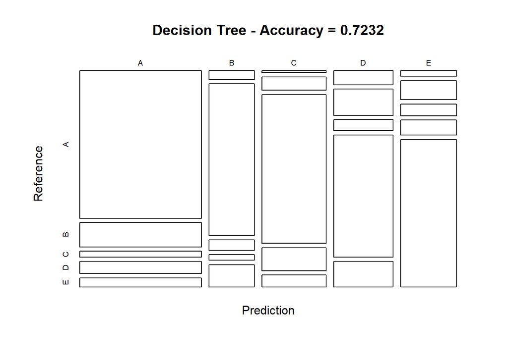

```r
# Plotting matrix results
plot(confdeTree$table, col = confdeTree$byClass,main = paste("Decision Tree - Accuracy =",
     round(confdeTree$overall['Accuracy'], 4)))
```

### Generalized Boosted Model

```r
# Fitting the model
set.seed(12345)
controlGbm <- trainControl(method = "repeatedcv", number = 5, repeats = 1)
modfitGbm  <- train(classe ~ ., data=Trainset, method = "gbm",
                    trControl = controlGbm, verbose = FALSE)
modfitGbm$finalModel
```

```
## A gradient boosted model with multinomial loss function.
## 150 iterations were performed.
## There were 53 predictors of which 53 had non-zero influence.
```

```r
# Prediction on Test dataset
predictGbm <- predict(modfitGbm, newdata=Testset)
confmatGbm <- confusionMatrix(predictGbm, as.factor(Testset$classe))
confmatGbm
```

```
## Confusion Matrix and Statistics
##
##           Reference
## Prediction    A    B    C    D    E
##          A 1670    7    0    1    0
##          B    4 1123   11    4    3
##          C    0    8 1010    9    3
##          D    0    1    5  950   12
##          E    0    0    0    0 1064
##
## Overall Statistics
##
##                Accuracy : 0.9884
##                  95% CI : (0.9854, 0.991)
##     No Information Rate : 0.2845
##     P-Value [Acc > NIR] : < 2.2e-16
##
##                   Kappa : 0.9854
##
##  Mcnemar's Test P-Value : NA
##
## Statistics by Class:
##
##                      Class: A Class: B Class: C Class: D Class: E
## Sensitivity            0.9976   0.9860   0.9844   0.9855   0.9834
## Specificity            0.9981   0.9954   0.9959   0.9963   1.0000
## Pos Pred Value         0.9952   0.9808   0.9806   0.9814   1.0000
## Neg Pred Value         0.9990   0.9966   0.9967   0.9972   0.9963
## Prevalence             0.2845   0.1935   0.1743   0.1638   0.1839
## Detection Rate         0.2838   0.1908   0.1716   0.1614   0.1808
## Detection Prevalence   0.2851   0.1946   0.1750   0.1645   0.1808
## Balanced Accuracy      0.9979   0.9907   0.9901   0.9909   0.9917
```

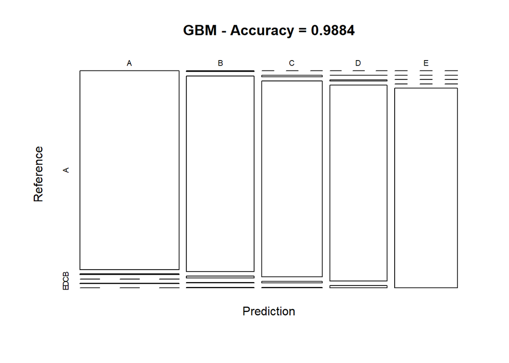

```r
# plot matrix results
plot(confmatGbm$table, col = confmatGbm$byClass,
     main = paste("GBM - Accuracy =", round(confmatGbm$overall['Accuracy'], 4)))
```

## Taking the best model and applying the data

So from the above three models we will be using Random Forest to the 20 quiz results.

```r
results <- predict(modfitRandForest, newdata=testing)
results
```

```
##  [1] B A B A A E D B A A B C B A E E A B B B
## Levels: A B C D E
```